# Homework 5

Yiming Gao (NetID: yimingg2)

2017/3/6

# Exercise 1

We use KNN to make classifications. First we coerce the response `class` to be a factor. Since `knn()` requires the predictors be their own data frame or matrix, and the class lables be a separate factor variable. We separate the training and test set.

```r
# Some functions
accuracy <- function(actual, predicted) {
  mean(actual == predicted)
}

get_pred = function(mod, data, res = "y", pos = 1, neg = 0, cut = 0.5) {
  probs = predict(mod, newdata = data, type = "response")
  ifelse(probs > cut, pos, neg)
}

train_data$class = factor(train_data$class)
test_data$class = factor(test_data$class)
# training data
X_train = train_data[, -1]
y_train = train_data$class

# test data
X_test = test_data[, -1]
y_test = test_data$class
```

We consider $k = 1,2,...,50$ and find the best $k$ using both scaled and unscaled predictors.

## Scaled Predictors

```r
set.seed(314)
k_to_try = 1:50
acc_k_train_scaled <- acc_k_test_scaled <- rep(0, length(k_to_try))

for (i in seq_along(k_to_try)) {
  pred_train_scaled = knn(train = scale(X_train),
                          test = scale(X_train),
                          cl = y_train,
                          k = k_to_try[i])
  pred_test_scaled = knn(train = scale(X_train),
                         test = scale(X_test),
                         cl = y_train,
                         k = k_to_try[i])
  acc_k_train_scaled[i] = accuracy(y_train, pred_train_scaled)
  acc_k_test_scaled[i] = accuracy(y_test, pred_test_scaled)
}

c(max(acc_k_test_scaled), max(which(acc_k_test_scaled == max(acc_k_test_scaled))))
```

```
## [1]  0.92 44.00
```

Then we plot training and test accuracy vs $k$ on a single plot.

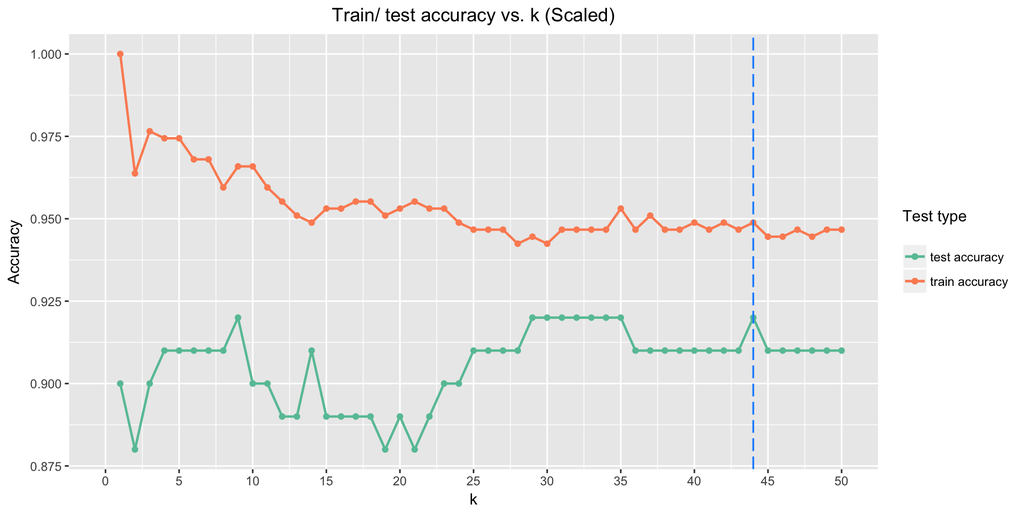

```r
mydata_scaled = data.frame("k" = k_to_try, "train" = acc_k_train_scaled, "test" = acc_k_test_scaled)

ggplot(mydata_scaled, aes(k)) + scale_x_continuous(breaks = seq(0, 50, 5), limits = c(0, 50)) +
  geom_point(aes(y = train, colour = "train accuracy")) +
  geom_line(aes(y = train, colour = "train accuracy"), se = FALSE, size = 0.8) +
  geom_point(aes(y = test, colour = "test accuracy")) +
  geom_line(aes(y = test, colour = "test accuracy"), se = FALSE, size = 0.8) +
  geom_vline(xintercept = 44, colour = "dodgerblue", size = 0.6, linetype = "longdash") +
  labs(title = "Train/ test accuracy vs. k (Scaled)" , x = "k", y = "Accuracy", color = "Test type\n") +
  theme(plot.title = element_text(hjust = 0.5)) + scale_colour_brewer(palette = "Set2")
```

## Unscaled Predictors

```r
set.seed(314)
k_to_try = 1:50
acc_k_train_unscaled <- acc_k_test_unscaled <- rep(0, length(k_to_try))

for (i in seq_along(k_to_try)) {
  pred_train_unscaled = knn(train = X_train,
                            test = X_train,
                            cl = y_train,
                            k = k_to_try[i])
  pred_test_unscaled = knn(train = X_train,
                           test = X_test,
                           cl = y_train,
                           k = k_to_try[i])
  acc_k_train_unscaled[i] = accuracy(y_train, pred_train_unscaled)
  acc_k_test_unscaled[i] = accuracy(y_test, pred_test_unscaled)
}

c(max(acc_k_test_unscaled), max(which(acc_k_test_unscaled == max(acc_k_test_unscaled))))
```

```
## [1] 0.88 4.00
```

We see the largest test accuracy is 0.88 when $k=4$. Then we plot training and test accuracy vs $k$ on a single plot.

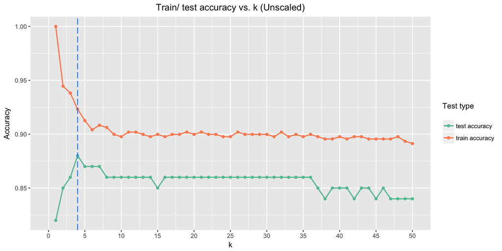

```r
mydata_unscaled = data.frame("k" = k_to_try, "train" = acc_k_train_unscaled, "test" = acc_k_test_unscaled)

ggplot(mydata_unscaled, aes(k)) + scale_x_continuous(breaks = seq(0, 50, 5), limits = c(0, 50)) +
  geom_point(aes(y = train, colour = "train accuracy")) +
  geom_line(aes(y = train, colour = "train accuracy"), se = FALSE, size = 0.8) +
  geom_point(aes(y = test, colour = "test accuracy")) +
  geom_line(aes(y = test, colour = "test accuracy"), se = FALSE, size = 0.8) +
  geom_vline(xintercept = 4, colour = "dodgerblue", size = 0.6, linetype = "longdash") +
  labs(title = "Train/ test accuracy vs. k (Unscaled)", x = "k", y = "Accuracy", color = "Test type\n") +
  theme(plot.title = element_text(hjust = 0.5)) + scale_colour_brewer(palette = "Set2")
```

We notice that when test accuracy reaches its highest, k = 4, which is a complex model. Compared to larger k, this model may be overfitting.

We summarize the information into the following table:

| Model | Best k | Associated test accuracy |
| --- | --- | --- |
| Scaled | 44 | 0.92 |
| Unscaled | 4 | 0.88 |

From the table, we notice *scaling* gives a **simpler model** with **higher test accuracy**, so it is helpful.

# Exercise 2

In this problem, we calculate *train*, *test*, and *5-fold* *cross-validated* accuracy for both an **additive logistic regression** and **LDA**.

```r
uin = 650379994
set.seed(uin)

# cross-validation
folds = caret::createFolds(train_data$class, k = 5)

# additive logistic regression
add = glm(ifelse(train_data$class == "M", 1, 0) ~ ., data = train_data, family = "binomial")

# LDA
lda = lda(class ~ ., data = train_data)

# Get accuracies
# Additive logistic accuracy
add_train_accuracy = accuracy(predicted = ifelse(get_pred(add, data = train_data, res = "class", pos = "1", neg = "0", cut = 0.5)==1, "M", "B"), actual = train_data$class)
add_test_accuracy = accuracy(predicted = ifelse(get_pred(add, data = test_data, res = "class", pos = "1", neg = "0", cut = 0.5)==1, "M", "B"), actual = test_data$class)

# LDA accuracy
lda_train_accuracy = accuracy(predicted = predict(lda, newdata = train_data)$class, actual = train_data$class)
lda_test_accuracy = accuracy(predicted = predict(lda, newdata = test_data)$class, actual = test_data$class)

# 5-fold cross-validation
fold_log_acc <- fold_lda_acc <- rep(0, 5)

for (i in 1:5) {
  fit_add = glm(ifelse(train_data[-folds[[i]], ]$class == "M", 1, 0) ~ ., data = train_data[-folds[[i]], ], family = "binomial")
  fit_lda = lda(class ~ ., data = train_data[-folds[[i]], ])

  # predictions and accuracies
  # additive logistic model
  fold_log_acc[i] = accuracy(predicted = ifelse(get_pred(fit_add, data = train_data[folds[[i]], ], res = "class", pos = "1", neg = "0", cut = 0.5)==1, "M", "B"), actual = train_data[folds[[i]], ]$class)

  # lda
  fold_lda_acc[i] = accuracy(predicted = predict(fit_lda, newdata = train_data[folds[[i]], ])$class, actual = train_data[folds[[i]], ]$class)
}
```

Then we calculate cross-validated accuracies for both the additive logistic regression and LDA.

```r
c(mean(fold_log_acc), mean(fold_lda_acc))
```

```
## [1] 0.9423682 0.9381801
```

We summarize the information into the following table:

| Model | Train accuracy | Test accuracy | Cross-validated accuracy |
| --- | --- | --- | --- |
| `Additive Logistic Regression` | 0.953 | 0.9 | 0.942 |
| `LDA` | 0.94 | 0.92 | 0.938 |

It seems that the cross-validation gives accuracies between training and test accuracy, which is what we expect.